# DataViz Makeover 3

Explore different perspectives and approaches to design more truthful and enlightening data visualisation,

## The Scene

A data journalist is tasked to prepare two data visualisation to support the news write-up of the latest development in DKI Jakarta. Below are the two data visualisation prepared by the data journalist.

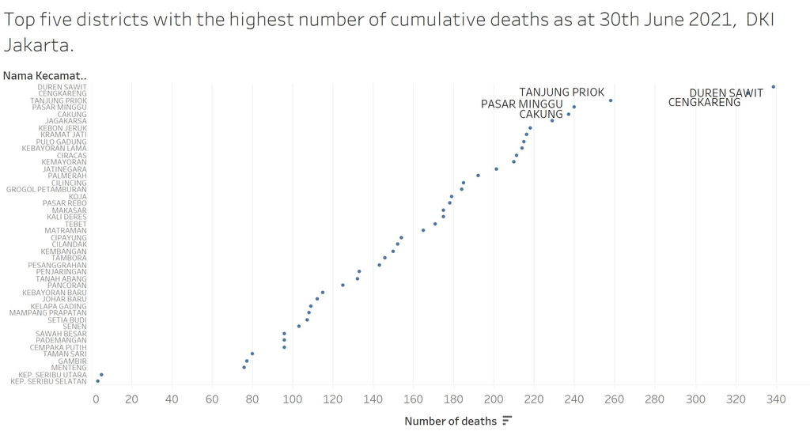

and

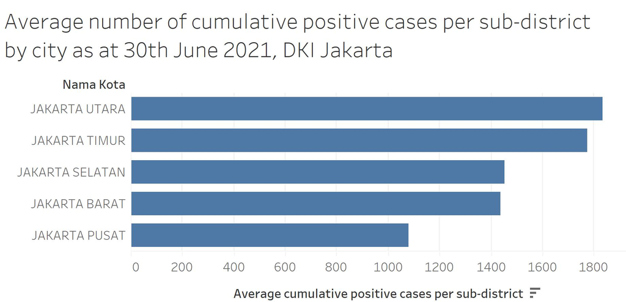

## The Task

1. Critic the data visualisation from both its clarity and aesthetics. At least three from each evaluation criterion. (15 marks)
2. With reference to the critics above, suggest alternative graphical presentation to improve the current design. Sketch out the proposed design. The proposed alternative design should include interactive techniques. Support your design by describing the advantages or which part of the issue(s) your alternative design try to overcome. (15 marks)
3. Using Tableau, design the proposed data visualisation. (25 marks)
4. Provide step-by-step description on how the data visualisation was prepared.  
   (30 marks)
5. Describe three major observations revealed by the data visualisation prepared. (15 marks)

## The Data

The data used to prepare the data visualisation is downloaded from [Open Data Covid-19 Provinsi DKI Jakarta](https://riwayat-file-covid-19-dki-jakarta-jakartagis.hub.arcgis.com/). For creating the data visualisation above, the file dated on *30 Juni 2021 Pukul 10.00* is used.

## Submission Instruction

Please refer to this [link](https://isss608.netlify.app/dataviz#submission-instructions).

## Submission date

25th July 2021 (Sunday), mid-night 11:59pm.

## For your eyes only

This dataviz makeover exercise have something to do with visualizing uncertainty. You should revised slides 24-38 of Lesson 4 and readings provided at this [section](https://isss608.netlify.app/outline/lesson04_outline#readings-on-visualising-uncertainty) of the course outline of Lesson 4.

## Peer Learning

### G1

- AHMAD FADY GANIS
  - DataViz Makeover write-up on Netlify and Tableau Public link
- ARCHIE QUIAMBAO DOLIT
  - DataViz Makeover write-up on Netlify and Tableau Public link
- ARYAH UMRALKAR CHOPRA
  - DataViz Makeover write-up on Netlify and Tableau Public link
- CHEN YUXI
  - DataViz Makeover write-up on Netlify and Tableau Public link
- CONNIE XIA YI JING
  - DataViz Makeover write-up on Netlify and Tableau Public link
- HONG YUN TING
  - DataViz Makeover write-up on Netlify and Tableau Public link
- HUANG LINYA
  - DataViz Makeover write-up on Netlify and Tableau Public link
- HUANG SHAN
  - DataViz Makeover write-up on Netlify and Tableau Public link
- JOVINKA HARTANTO
  - DataViz Makeover write-up on Netlify and Tableau Public link
- KELLY KOH KIA WOON
  - DataViz Makeover write-up on Netlify and Tableau Public link
- KEVIN MAGIC RIALUBIN SUNGA
  - DataViz Makeover write-up on Netlify and Tableau Public link
- LI SHUXIAN
  - DataViz Makeover write-up on Netlify and Tableau Public link
- LI YUHONG
  - DataViz Makeover write-up on Netlify and Tableau Public link
- LI YUMENG
  - DataViz Makeover write-up on Netlify and Tableau Public link
- LIAN YINGZHEN JOANNA
  - DataViz Makeover write-up on Netlify and Tableau Public link
- LIANG YINGFANG
  - DataViz Makeover write-up on Netlify and Tableau Public link
- LIM JIAHUI
  - DataViz Makeover write-up on Netlify and Tableau Public link
- LIM JIN RU
  - DataViz Makeover write-up on Netlify and Tableau Public link
- LIM YONG KAI
  - DataViz Makeover write-up on Netlify and Tableau Public link
- LIU YANGGUANG
  - DataViz Makeover write-up on Netlify and Tableau Public link
- LOH YUN JIA STELLA
  - DataViz Makeover write-up on Netlify and Tableau Public link
- LUO HAOYU
  - DataViz Makeover write-up on Netlify and Tableau Public link
- MANMIT SINGH S/O NARMAL SINGH
  - DataViz Makeover write-up on Netlify and Tableau Public link
- MAYURAPRIYANN ARULMOZHI BASKARAN
  - DataViz Makeover write-up on Netlify and Tableau Public link
- NG DING XUAN ARNOLD
  - DataViz Makeover write-up on Netlify and Tableau Public link
- NG YEN NGEE
  - DataViz Makeover write-up on Netlify and Tableau Public link
- NIKITHA BANDA
  - DataViz Makeover write-up on Netlify and Tableau Public link
- NURULASYIQAH BINTE MOHAMMAD TAHA
  - DataViz Makeover write-up on Netlify and Tableau Public link
- OH YAO WEI AARON
  - DataViz Makeover write-up on Netlify and Tableau Public link
- ONG CHEE HONG
  - DataViz Makeover write-up on Netlify and Tableau Public link
- RHODA TONG MIN TING
  - DataViz Makeover write-up on Netlify and Tableau Public link
- RYAN CHAN WEIYAO
  - DataViz Makeover write-up on Netlify and Tableau Public link
- SHEN XIAOJING
  - DataViz Makeover write-up on Netlify and Tableau Public link
- SYED AHMAD ZAKI BIN SYED SAKAF AL-ATTAS
  - DataViz Makeover write-up on Netlify and Tableau Public link
- TAN CHEE SENG DAVMES
  - DataViz Makeover write-up on Netlify and Tableau Public link
- TAN CHOO THYE
  - DataViz Makeover write-up on Netlify and Tableau Public link
- TAN KAR YEE
  - DataViz Makeover write-up on Netlify and Tableau Public link
- WANG QINYU
  - DataViz Makeover write-up on Netlify and Tableau Public link
- XU DAN
  - DataViz Makeover write-up on Netlify and Tableau Public link
- YAN RUIYUN
  - DataViz Makeover write-up on Netlify and Tableau Public link
- YANG XU
  - DataViz Makeover write-up on Netlify and Tableau Public link
- YEO CHIA GUAN ANDY
  - DataViz Makeover write-up on Netlify and Tableau Public link
- YEO DING RUN
  - DataViz Makeover write-up on Netlify and Tableau Public link
- YU YAXIN
  - DataViz Makeover write-up on Netlify and Tableau Public link
- ZHANG YING
  - DataViz Makeover write-up on Netlify and Tableau Public link
- ZHONG LINLI
  - DataViz Makeover write-up on Netlify and Tableau Public link

### G2

- BAI YINING
  - DataViz Makeover write-up on Netlify and Tableau Public link
- DONG FANG
  - DataViz Makeover write-up on Netlify and Tableau Public link
- JESSICA TAN SOO CHENG
  - DataViz Makeover write-up on Netlify and Tableau Public link
- JOYCE WOON SHI HUI
  - DataViz Makeover write-up on Netlify and Tableau Public link
- LANG SHUANG
  - DataViz Makeover write-up on Netlify and Tableau Public link
- LEE SULING
  - DataViz Makeover write-up on Netlify and Tableau Public link
- LI NAN
  - DataViz Makeover write-up on Netlify and Tableau Public link
- LI YUETING
  - DataViz Makeover write-up on Netlify and Tableau Public link
- LI ZHEN
  - DataViz Makeover write-up on Netlify and Tableau Public link
- LIN PEIRONG
  - DataViz Makeover write-up on Netlify and Tableau Public link
- LIU MANYE
  - DataViz Makeover write-up on Netlify and Tableau Public link
- LIU NIAN
  - DataViz Makeover write-up on Netlify and Tableau Public link
- LU DI
  - DataViz Makeover write-up on Netlify and Tableau Public link
- MAO XIAOZHU
  - DataViz Makeover write-up on Netlify and Tableau Public link
- MIAO LU
  - DataViz Makeover write-up on Netlify and Tableau Public link
- MISHRA AMRITA
  - DataViz Makeover write-up on Netlify and Tableau Public link
- QIAN ZIWEI
  - DataViz Makeover write-up on Netlify and Tableau Public link
- SNG KAH LEONG
  - DataViz Makeover write-up on Netlify and Tableau Public link
- TANG HUINING
  - DataViz Makeover write-up on Netlify and Tableau Public link
- TANG YUE
  - DataViz Makeover write-up on Netlify and Tableau Public link
- VERTIKA PODDAR
  - DataViz Makeover write-up on Netlify and Tableau Public link
- WANG JIAYI
  - DataViz Makeover write-up on Netlify and Tableau Public link
- WANG XIYU
  - DataViz Makeover write-up on Netlify and Tableau Public link
- YIN XIAOLAN
  - DataViz Makeover write-up on Netlify and Tableau Public link
- ZHANG XINRU
  - DataViz Makeover write-up on Netlify and Tableau Public link
- ZHANG YOUZHEN
  - DataViz Makeover write-up on Netlify and Tableau Public link
- ZHONG PING
  - DataViz Makeover write-up on Netlify and Tableau Public link